# Carbon Footprint of Nations

2026-11-22

```r
library(tidyverse)
library(ggplot2)
```

## Analisi dei dati

```r
df <- read_csv("owid-co2-data.csv")
colnames(df)
```

```
##  [1] "country"
##  [2] "year"
##  [3] "iso_code"
##  [4] "population"
##  [5] "gdp"
##  [6] "cement_co2"
##  [7] "cement_co2_per_capita"
##  [8] "co2"
##  [9] "co2_growth_abs"
## [10] "co2_growth_prct"
## [11] "co2_including_luc"
## [12] "co2_including_luc_growth_abs"
## [13] "co2_including_luc_growth_prct"
## [14] "co2_including_luc_per_capita"
## [15] "co2_including_luc_per_gdp"
```

[output cut: 64 more lines]

```r
df1 <- df |>
  select(country, iso_code, year, population, gdp,
         co2, cumulative_co2,
         coal_co2, gas_co2, oil_co2, other_industry_co2) |>
  rename(other_co2 = other_industry_co2) |>
  mutate(co2_pc = co2 / population,
         coal_co2_pc = coal_co2 / population,
         gas_co2_pc = gas_co2 / population,
         oil_co2_pc = oil_co2 / population) |>
  mutate(other_co2 = co2 - (coal_co2 + gas_co2 + oil_co2)) |>
  mutate(other_co2_pc = other_co2 / population)
df1
```

```
## # A tibble: 56,269 × 16
##    country iso_code  year population   gdp   co2 cumulative_co2 coal_co2 gas_co2
##    <chr>   <chr>    <dbl>      <dbl> <dbl> <dbl>          <dbl>    <dbl>   <dbl>
##  1 Afghan… AFG       1750    2802560    NA    NA             NA       NA      NA
##  2 Afghan… AFG       1751         NA    NA    NA             NA       NA      NA
##  3 Afghan… AFG       1752         NA    NA    NA             NA       NA      NA
##  4 Afghan… AFG       1753         NA    NA    NA             NA       NA      NA
##  5 Afghan… AFG       1754         NA    NA    NA             NA       NA      NA
##  6 Afghan… AFG       1755         NA    NA    NA             NA       NA      NA
##  7 Afghan… AFG       1756         NA    NA    NA             NA       NA      NA
##  8 Afghan… AFG       1757         NA    NA    NA             NA       NA      NA
##  9 Afghan… AFG       1758         NA    NA    NA             NA       NA      NA
## 10 Afghan… AFG       1759         NA    NA    NA             NA       NA      NA
## # ℹ 56,259 more rows
## # ℹ 7 more variables: oil_co2 <dbl>, other_co2 <dbl>, co2_pc <dbl>,
## #   coal_co2_pc <dbl>, gas_co2_pc <dbl>, oil_co2_pc <dbl>, other_co2_pc <dbl>
```

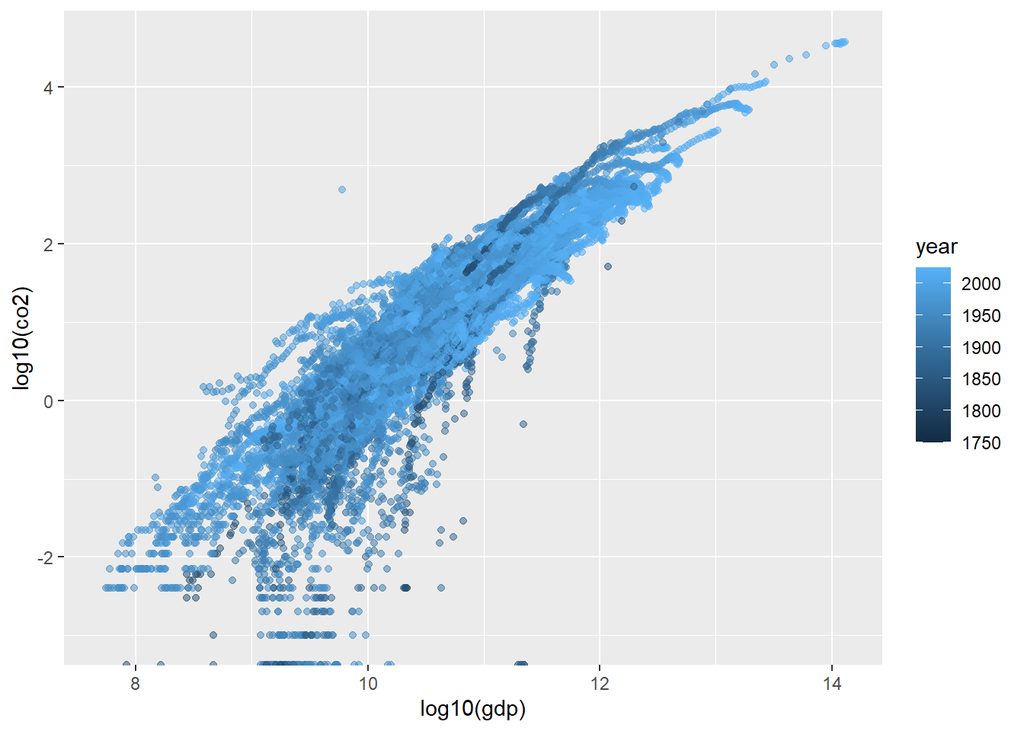

```r
ggplot(data = df1, mapping = aes(x = log10(gdp), y = log10(co2), color = year)) +
  geom_point(alpha = 0.5)
```

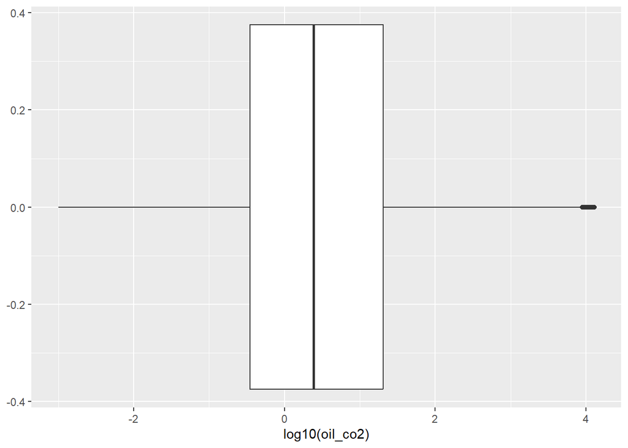

```r
ggplot(data = df1, mapping = aes(x = log10(oil_co2))) +
  geom_boxplot()
```

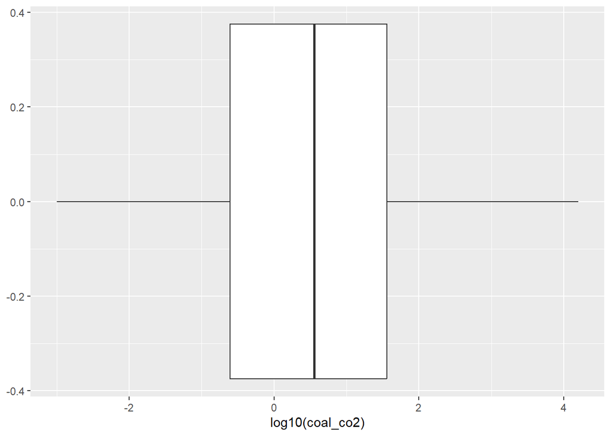

```r
ggplot(data = df1, mapping = aes(x = log10(coal_co2))) +
  geom_boxplot()
```

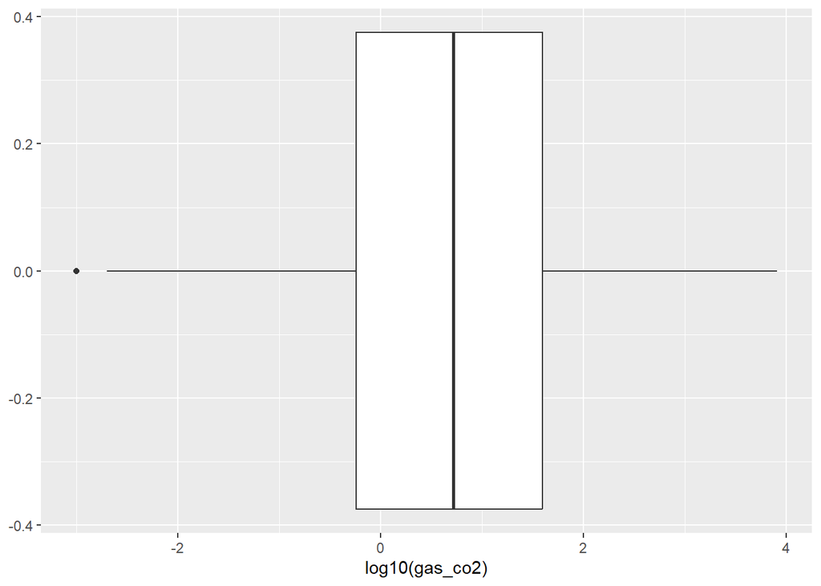

```r
ggplot(data = df1, mapping = aes(x = log10(gas_co2))) +
  geom_boxplot()
```

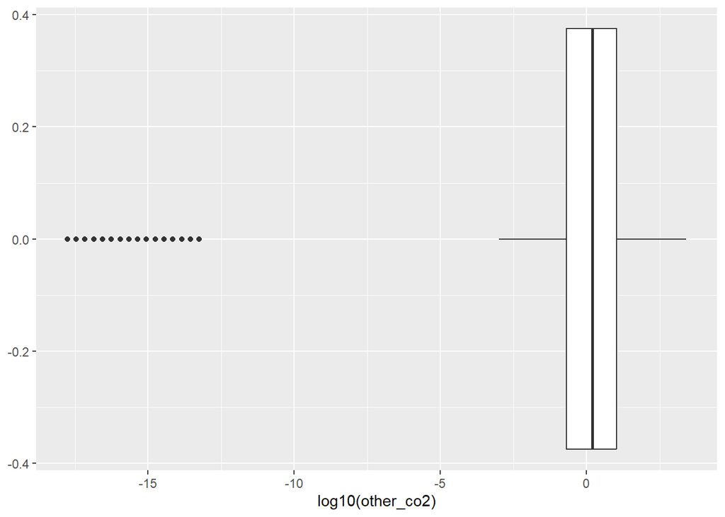

```r
ggplot(data = df1, mapping = aes(x = log10(other_co2))) +
  geom_boxplot()
```

Non siamo interessati alle righe che non rappresentano degli stati. Raggruppo i dati a gruppi di 25 anni per ogni nazione, sostituendo alle colonne numeriche la media dei valori non NA.

```r
df2 <- df1 |>
  filter(! is.na(iso_code)) |>
  mutate(century_block = (year - 1750) %/% 25) |>
  group_by(country, iso_code, century_block) |>
  summarise(population = mean(population, na.rm = TRUE),
            gdp = mean(gdp, na.rm = TRUE),
            co2 = mean(co2, na.rm = TRUE),
            cumulative_co2 = max(cumulative_co2, na.rm = TRUE),
            coal_co2 = mean(coal_co2, na.rm = TRUE),
            oil_co2 = mean(oil_co2, na.rm = TRUE),
            gas_co2 = mean(gas_co2, na.rm = TRUE),
            other_co2 = mean(other_co2, na.rm = TRUE),
            co2_pc = mean(co2_pc, na.rm = TRUE),
            coal_co2_pc = mean(coal_co2_pc, na.rm = TRUE),
            oil_co2_pc = mean(oil_co2_pc, na.rm = TRUE),
            gas_co2_pc = mean(gas_co2_pc, na.rm = TRUE),
            other_co2_pc = mean(other_co2_pc, na.rm = TRUE),
            )
df2
```

```
## # A tibble: 2,163 × 16
## # Groups:   country, iso_code [223]
##    country    iso_code century_block population       gdp     co2 cumulative_co2
##    <chr>      <chr>            <dbl>      <dbl>     <dbl>   <dbl>          <dbl>
##  1 Afghanist… AFG                  0   2866737. NaN       NaN           -Inf
##  2 Afghanist… AFG                  1   3032088. NaN       NaN           -Inf
##  3 Afghanist… AFG                  2   3286493. NaN       NaN           -Inf
##  4 Afghanist… AFG                  3   3540528. NaN       NaN           -Inf
##  5 Afghanist… AFG                  4   3959325. NaN       NaN           -Inf
##  6 Afghanist… AFG                  5   4425782. NaN       NaN           -Inf
##  7 Afghanist… AFG                  6   6943225. NaN       NaN           -Inf
##  8 Afghanist… AFG                  7   6846229. NaN         0.015          0.015
##  9 Afghanist… AFG                  8   9676158.   1.29e10   0.744         18.6
## 10 Afghanist… AFG                  9  13734669.   1.41e10   2.05          70.0
## # ℹ 2,153 more rows
## # ℹ 9 more variables: coal_co2 <dbl>, oil_co2 <dbl>, gas_co2 <dbl>,
## #   other_co2 <dbl>, co2_pc <dbl>, coal_co2_pc <dbl>, oil_co2_pc <dbl>,
## #   gas_co2_pc <dbl>, other_co2_pc <dbl>
```

```r
df3 <- df2 |>
  mutate(cumulative_co2 = pmax(cumulative_co2, 0)) |> # Al posto di -Inf metto 0
  filter(! is.na(co2)) # Non ci interessano i blocchi in cui non abbiamo dati sulla co2
df3
```

```
## # A tibble: 1,266 × 16
## # Groups:   country, iso_code [220]
##    country     iso_code century_block population       gdp    co2 cumulative_co2
##    <chr>       <chr>            <dbl>      <dbl>     <dbl>  <dbl>          <dbl>
##  1 Afghanistan AFG                  7   6846229. NaN        0.015          0.015
##  2 Afghanistan AFG                  8   9676158.   1.29e10  0.744         18.6
##  3 Afghanistan AFG                  9  13734669.   1.41e10  2.05          70.0
##  4 Afghanistan AFG                 10  30918071.   4.58e10  6.51         233.
##  5 Afghanistan AFG                 11  43844116  NaN       11.2          244.
##  6 Albania     ALB                  7   1076390.   1.44e 9  0.421          7.17
##  7 Albania     ALB                  8   1771687.   4.58e 9  2.58          71.7
##  8 Albania     ALB                  9   3013596.   1.08e10  5.12         200.
##  9 Albania     ALB                 10   2958295.   2.61e10  4.56         314.
## 10 Albania     ALB                 11   2771507  NaN        4.64         318.
## # ℹ 1,256 more rows
## # ℹ 9 more variables: coal_co2 <dbl>, oil_co2 <dbl>, gas_co2 <dbl>,
## #   other_co2 <dbl>, co2_pc <dbl>, coal_co2_pc <dbl>, oil_co2_pc <dbl>,
## #   gas_co2_pc <dbl>, other_co2_pc <dbl>
```

```r
df3 |> filter(is.na(gdp)) |> nrow()
```

```
## [1] 571
```

Visto che per 571 dati su 1266 non abbiamo informazioni sul gdp, scegliamo di escluderlo dalla rappresentazione artistica (e dallo studio).

```r
df4 <- df3 |>
  select(-gdp)
df4
```

```
## # A tibble: 1,266 × 15
## # Groups:   country, iso_code [220]
##    country     iso_code century_block population    co2 cumulative_co2 coal_co2
##    <chr>       <chr>            <dbl>      <dbl>  <dbl>          <dbl>    <dbl>
##  1 Afghanistan AFG                  7   6846229.  0.015          0.015  0.015
##  2 Afghanistan AFG                  8   9676158.  0.744         18.6    0.209
##  3 Afghanistan AFG                  9  13734669.  2.05          70.0    0.264
##  4 Afghanistan AFG                 10  30918071.  6.51         233.     1.29
##  5 Afghanistan AFG                 11  43844116  11.2          244.     0.668
##  6 Albania     ALB                  7   1076390.  0.421          7.17   0.00171
##  7 Albania     ALB                  8   1771687.  2.58          71.7    0.459
##  8 Albania     ALB                  9   3013596.  5.12         200.     1.95
##  9 Albania     ALB                 10   2958295.  4.56         314.     0.404
## 10 Albania     ALB                 11   2771507   4.64         318.     0.514
## # ℹ 1,256 more rows
## # ℹ 8 more variables: oil_co2 <dbl>, gas_co2 <dbl>, other_co2 <dbl>,
## #   co2_pc <dbl>, coal_co2_pc <dbl>, oil_co2_pc <dbl>, gas_co2_pc <dbl>,
## #   other_co2_pc <dbl>
```

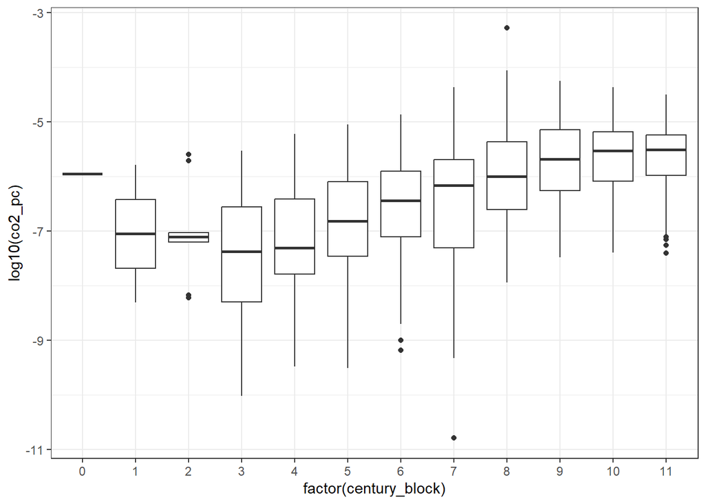

```r
ggplot(data = df4, mapping = aes(x = factor(century_block), y = log10(co2_pc))) +
  geom_boxplot() +
  theme_bw()
```

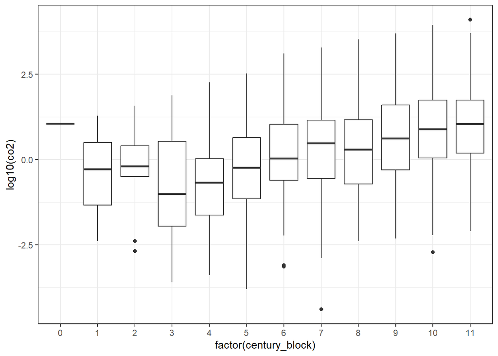

```r
ggplot(data = df4, mapping = aes(x = factor(century_block), y = log10(co2))) +
  geom_boxplot() +
  theme_bw()
```

Si nota un aumento della co2 pro capite al passare del tempo.

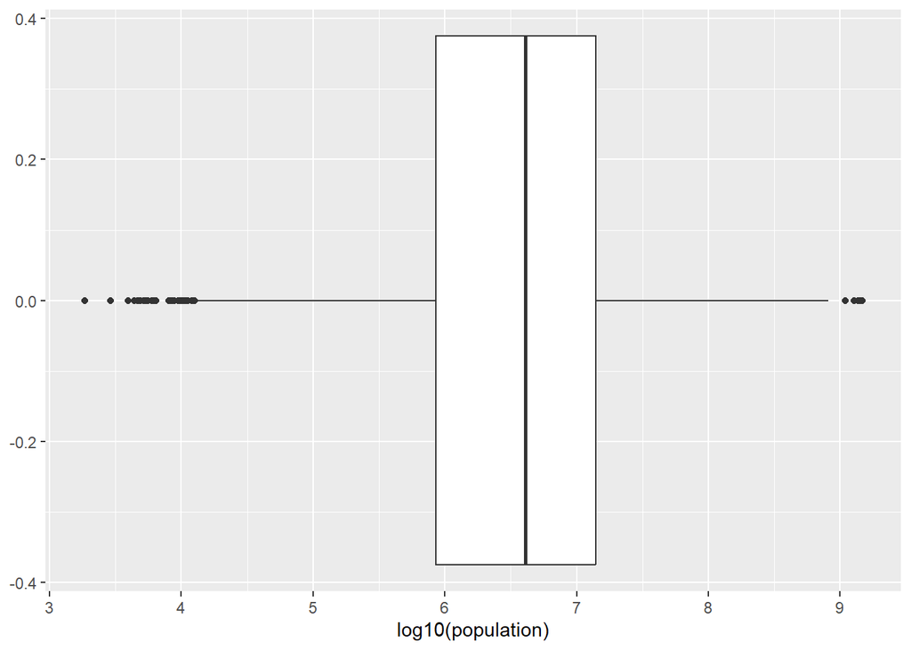

```r
ggplot(data = df3, mapping = aes(x = log10(population))) +
  geom_boxplot()
```

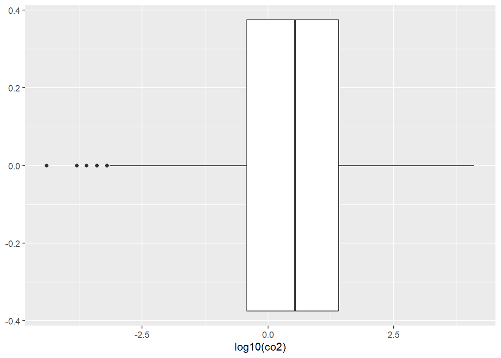

```r
ggplot(data = df3, mapping = aes(x = log10(co2))) +
  geom_boxplot()
```

## Data art

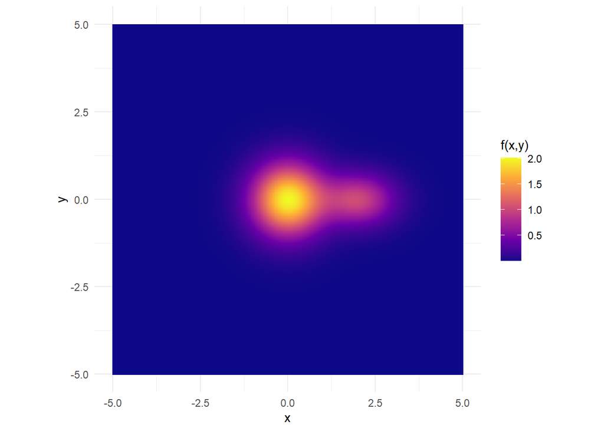

```r
f <- function(x, y) {
  2 * exp(-(x^2 + y^2)) +
    exp(-((x - 2)^2 + 2*y^2))
}

grid <- expand.grid(
  x = seq(-5, 5, length.out = 300),
  y = seq(-5, 5, length.out = 300)
)

grid <- grid |>
  mutate(z = f(x, y))

ggplot(grid, aes(x = x, y = y, fill = z)) +
  geom_raster() +
  scale_fill_viridis_c(
    option = "plasma",
    name = "f(x,y)"
  ) +
  coord_equal() +
  theme_minimal()
```

```r
df5 <- df4 |>
  select(country, iso_code, century_block, population, co2_pc, co2) |>
  na.omit() # Elimino tutte le righe senza popolazione o senza co2_pc o co2
df5
```

```
## # A tibble: 1,251 × 6
## # Groups:   country, iso_code [218]
##    country     iso_code century_block population        co2_pc    co2
##    <chr>       <chr>            <dbl>      <dbl>         <dbl>  <dbl>
##  1 Afghanistan AFG                  7   6846229. 0.00000000204  0.015
##  2 Afghanistan AFG                  8   9676158. 0.0000000700   0.744
##  3 Afghanistan AFG                  9  13734669. 0.000000161    2.05
##  4 Afghanistan AFG                 10  30918071. 0.000000197    6.51
##  5 Afghanistan AFG                 11  43844116  0.000000255   11.2
##  6 Albania     ALB                  7   1076390. 0.000000367    0.421
##  7 Albania     ALB                  8   1771687. 0.00000135     2.58
##  8 Albania     ALB                  9   3013596. 0.00000174     5.12
##  9 Albania     ALB                 10   2958295. 0.00000155     4.56
## 10 Albania     ALB                 11   2771507  0.00000167     4.64
## # ℹ 1,241 more rows
```

```r
library(sf)
library(rnaturalearth)
```

```r
world <- ne_countries(
  scale = "medium",
  returnclass = "sf"
)

centroids <- world |>
  st_transform(3857) |>
  st_point_on_surface() |>
  st_transform(4326)

coords <- centroids |>
  mutate(
    longitude = st_coordinates(geometry)[, 1],
    latitude  = st_coordinates(geometry)[, 2]
  ) |>
  st_drop_geometry() |>
  select(iso_a3, latitude, longitude)

df6 <- df5 |>
  left_join(coords, by = c("iso_code" = "iso_a3"))
df6
```

```
## # A tibble: 1,251 × 8
## # Groups:   country, iso_code [218]
##    country   iso_code century_block population  co2_pc    co2 latitude longitude
##    <chr>     <chr>            <dbl>      <dbl>   <dbl>  <dbl>    <dbl>     <dbl>
##  1 Afghanis… AFG                  7   6846229. 2.04e-9  0.015     34.0      65.2
##  2 Afghanis… AFG                  8   9676158. 7.00e-8  0.744     34.0      65.2
##  3 Afghanis… AFG                  9  13734669. 1.61e-7  2.05      34.0      65.2
##  4 Afghanis… AFG                 10  30918071. 1.97e-7  6.51      34.0      65.2
##  5 Afghanis… AFG                 11  43844116  2.55e-7 11.2       34.0      65.2
##  6 Albania   ALB                  7   1076390. 3.67e-7  0.421     41.2      20.0
##  7 Albania   ALB                  8   1771687. 1.35e-6  2.58      41.2      20.0
##  8 Albania   ALB                  9   3013596. 1.74e-6  5.12      41.2      20.0
##  9 Albania   ALB                 10   2958295. 1.55e-6  4.56      41.2      20.0
## 10 Albania   ALB                 11   2771507  1.67e-6  4.64      41.2      20.0
## # ℹ 1,241 more rows
```

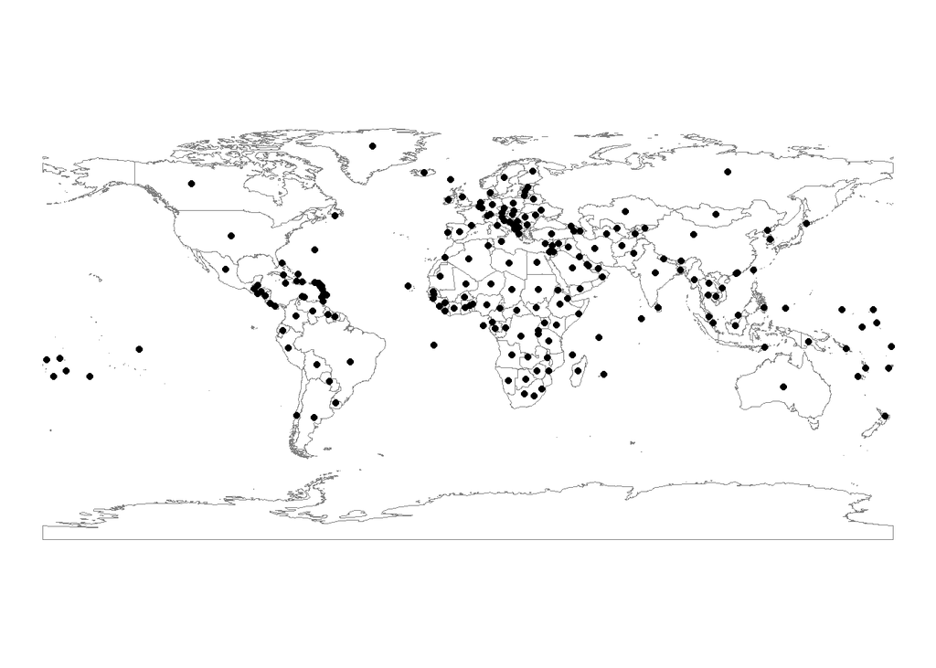

```r
ggplot() +
  geom_sf(
    data = world,
    fill = NA,
    color = "grey50",
    linewidth = 0.2
  ) +
  geom_point(data = df6, mapping = aes(x = longitude, y = latitude)) +
  theme_void()
```

```r
library(ggforce)
```

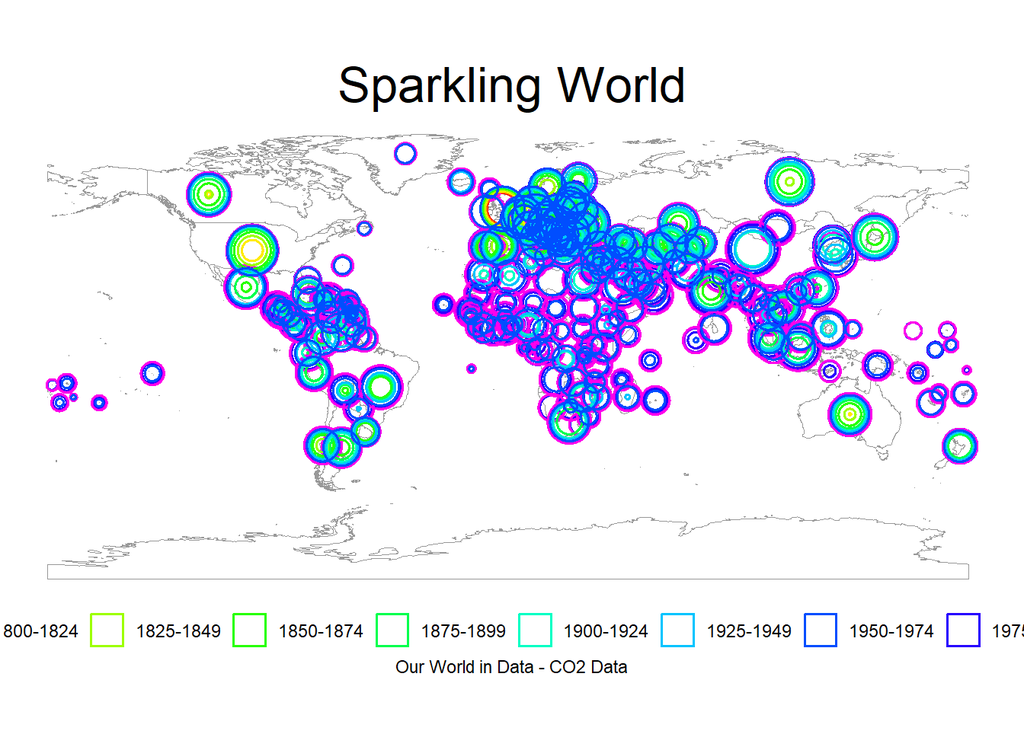

```r
etichette <- function(x) {
  a <- 1750 + 25 * as.numeric(as.character(x))
  b <- a + 24
  paste0(a, "-", b)
}

ggplot() +
  geom_sf(
    data = world,
    fill = NA,
    color = "grey60",
    linewidth = 0.2
  ) +
  geom_circle(data = df6, mapping = aes(
    x0 = longitude,
    y0 = latitude,
    r = 1.5 * (3 + log10(co2)),
    color = factor(century_block)
  ),
  linewidth = 0.6,
  alpha = 0.1) +
  scale_color_manual(
    values = rainbow(length(unique(df6$century_block)) + 1),
    labels = etichette,
    name = NULL, #"Historycal period"
    guide = guide_legend(nrow = 1, ncol = 12, byrow = TRUE) #"none"
  ) +
  scale_linewidth_continuous(guide = "none") +
  theme_void() +
  theme(
    legend.position = "bottom",
    plot.title = element_text(size = 24, hjust = 0.5),
    plot.subtitle = element_text(size = 16),
    plot.title.position = "plot",
    plot.caption = element_text(hjust = 0.5),
    plot.caption.position = "plot"
  ) +
  labs(
    title = "Sparkling World",
    #subtitle = "Subtitle",
    caption = "Our World in Data - CO2 Data"
  )
```

```r
ggsave("SparklingWorld.jpg", width = 16, height = 9, dpi = 300)
```

## Spiegazione del mapping della data art

### Origine dell’opera

Per ogni stato del mondo, centrati sul suo territorio, sono riportati 12 cerchi (o meno, in assenza dei dati) corrispondendi a 12 periodi storici da un quarto di secolo l’uno. Il raggio dei cerchi è linearmente proporzionale al logaritmo della quantità di CO2 prodotta.

### Significato

I numerosi cerchi ricordano le bolle visibili in un bicchiere di acqua frizzante (da cui il titolo dell’opera). Visto che visivamente le bolle diventano sempre più grandi, si percepisce l’aumento di anidride carbonica nell’aria al passare del tempo… Forse potremmo cambiare bevanda preferita, per riuscire a ridurre le bolle.